# Travaux pratiques 1

Laurent

2/19/2020

## Objectifs

L’objectif de ce TP est d’appréhender la mise en oeuvre d’un rapport automatique en Rmarkdown, ce qui signifie mélanger texte et analyses à partir de données ouvertes. Ce rapport traitera du calcul du descripteur D5C2 de la Directive Cadre Stratégie pour le milieu marin.

## Données

Nous allons utiliser des données issues de l’observation satellitales de la couleur de l’eau permettant de quantifier la concentration en chlorophylle a du milieu.

## Outils

### Rappels et consignes de moindre importance

R est un logiciel dédié à l’anlyse de données. RStutio est un environnement de travail intégré qui permet de faciliter le travail sous R.

- `getwd()` et `setwd()` permette de renseigner ou de positionner R dans un répertoire de travail donné.
- `NA` signifie donnée manquante.
- `print()` affiche le contenu d’un objet ou un résumé de ce dernier.
- `head()` affiche les 10 premières valeurs d’un objet.
- `tail()` affiche les 10 dernières valeurs d’un objet.
- pour installer une librairie (package) : `install.package("nomdupackage")`.
- le travail est à mener en utilisant un script.
- Pensez à enregistrer votre script.
- Pensez à enregistrer votre script.

### Pré-requis (?) :

- R via RStudio installé,
- savoir utiliser l’aide (comprendre l’usage d’une fonction et ses paramètres)
- installer un package : menu Outils/Tools ou la commande install.packages().
- savoir positionner son environnement de travail : getwd(), setwd() et retrouver des objets téléchargés sur son disque dur dans R.
- un peu de statistique, des notions de SIG et c’est tout.

## Librairies nécessaires

Utiliser RStudio pour installer les librairies suivantes :

```r
library(ncdf4) #si cela ne fonctionne pas me l'indiquer
library(raster)
library(rasterVis)
```

```r
library(mapdata)
library(maps)
```

## Données

Soit : - https://marine.copernicus.eu/ - -> ocean products - -> OCEANCOLOUR_GLO_CHL_L4_REP_OBSERVATIONS_009_082 - add to cart - puis cart -> download product - choose a dataset -> dataset-oc-glo-bio-multi-l4-chl_4km_monthly-rep - renseigner les coodonnées suivantes pour la baie de Seine : xmin=-1.5, xmax=0.8, ymin=49.2, ymax=49.7. - date 2010-01-02 à 2019-31-12 - download CHL seulement - cliquer sur download - enregisrer le fichier .nc sur votre disque

Soit utiliser les fichiers présents dans le répertoire data.

## Lire les données

### Fichier netcdf

```r
chl<-stack("../data/chl.nc")
```

### Fichier rasterbrick

```r
chl<-stack("../data/chl")
```

## Analyses exploratoires et manipulation des objets raster

## Cartographie de la zone d’étude

La zone d’étude est la suivante :

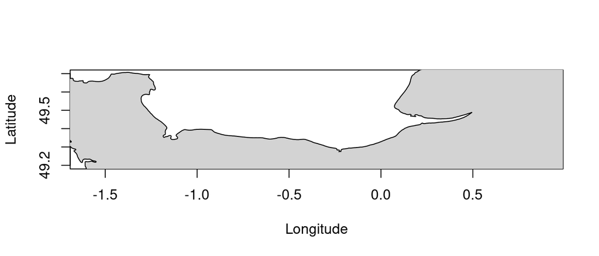

```r
#un plot vide
plot(1,xlim=c(-1.5,0.8),ylim=c(49.2,49.7),type="n",xlab="Longitude",ylab="Latitude",asp=1)
#le trait de côte
map("worldHires",xlim=c(-1.5,0.8),ylim=c(49.2,49.7),col="light grey",fill=T,add=T)
```

La baie de Seine donc.

## Manipulation de l’information

```r
dim(chl)
```

```
## [1]  13  55 120
```

```r
names(chl)
```

```
##   [1] "X2010.01.01" "X2010.02.01" "X2010.03.01" "X2010.04.01" "X2010.05.01"
##   [6] "X2010.06.01" "X2010.07.01" "X2010.08.01" "X2010.09.01" "X2010.10.01"
##  [11] "X2010.11.01" "X2010.12.01" "X2011.01.01" "X2011.02.01" "X2011.03.01"
##  [16] "X2011.04.01" "X2011.05.01" "X2011.06.01" "X2011.07.01" "X2011.08.01"
##  [21] "X2011.09.01" "X2011.10.01" "X2011.11.01" "X2011.12.01" "X2012.01.01"
##  [26] "X2012.02.01" "X2012.03.01" "X2012.04.01" "X2012.05.01" "X2012.06.01"
##  [31] "X2012.07.01" "X2012.08.01" "X2012.09.01" "X2012.10.01" "X2012.11.01"
##  [36] "X2012.12.01" "X2013.01.01" "X2013.02.01" "X2013.03.01" "X2013.04.01"
##  [41] "X2013.05.01" "X2013.06.01" "X2013.07.01" "X2013.08.01" "X2013.09.01"
##  [46] "X2013.10.01" "X2013.11.01" "X2013.12.01" "X2014.01.01" "X2014.02.01"
##  [51] "X2014.03.01" "X2014.04.01" "X2014.05.01" "X2014.06.01" "X2014.07.01"
##  [56] "X2014.08.01" "X2014.09.01" "X2014.10.01" "X2014.11.01" "X2014.12.01"
##  [61] "X2015.01.01" "X2015.02.01" "X2015.03.01" "X2015.04.01" "X2015.05.01"
##  [66] "X2015.06.01" "X2015.07.01" "X2015.08.01" "X2015.09.01" "X2015.10.01"
##  [71] "X2015.11.01" "X2015.12.01" "X2016.01.01" "X2016.02.01" "X2016.03.01"
##  [76] "X2016.04.01" "X2016.05.01" "X2016.06.01" "X2016.07.01" "X2016.08.01"
##  [81] "X2016.09.01" "X2016.10.01" "X2016.11.01" "X2016.12.01" "X2017.01.01"
##  [86] "X2017.02.01" "X2017.03.01" "X2017.04.01" "X2017.05.01" "X2017.06.01"
##  [91] "X2017.07.01" "X2017.08.01" "X2017.09.01" "X2017.10.01" "X2017.11.01"
##  [96] "X2017.12.01" "X2018.01.01" "X2018.02.01" "X2018.03.01" "X2018.04.01"
## [101] "X2018.05.01" "X2018.06.01" "X2018.07.01" "X2018.08.01" "X2018.09.01"
## [106] "X2018.10.01" "X2018.11.01" "X2018.12.01" "X2019.01.01" "X2019.02.01"
## [111] "X2019.03.01" "X2019.04.01" "X2019.05.01" "X2019.06.01" "X2019.07.01"
## [116] "X2019.08.01" "X2019.09.01" "X2019.10.01" "X2019.11.01" "X2019.12.01"
```

```r
str(chl)
```

[output not shown]

[output cut: 5510 more lines]

[output not shown]

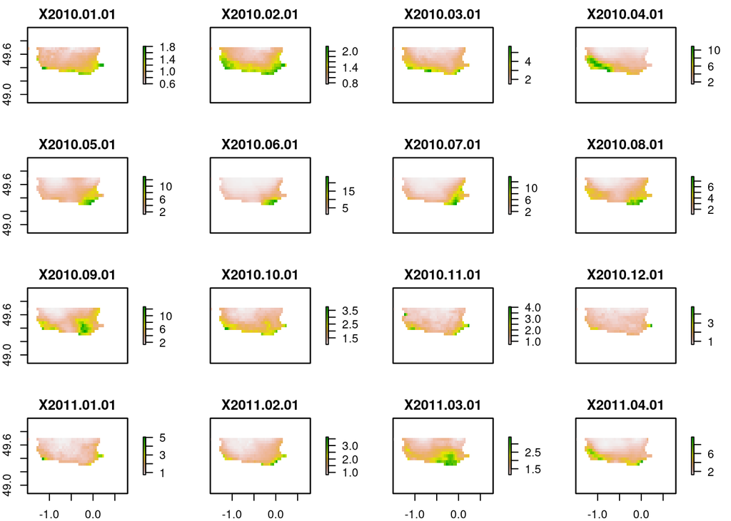

```r
#les cartes de chlorophylles
plot(chl)
```

[figure not shown]

```r
#plus joli
levelplot(chl)
```

[figure not shown]

```r
#encore plus joli
levelplot(chl,margin=F,zscale=T,contour=T,par.settings= viridisTheme,main="Chl 2010-2019")
```

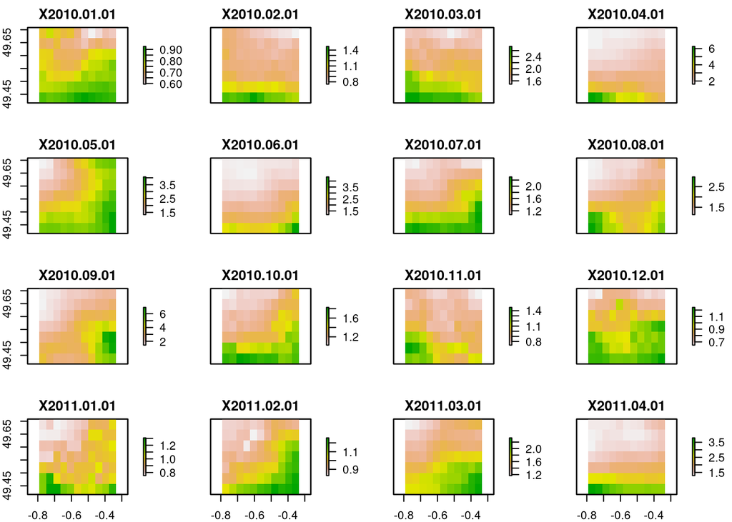

```r
#pour extraire une partie de l'image
#zone<-extent(-0.5,0,49.4,49.8)
zone<-extent(-0.8,-0.32,49.4,49.7)
#drawExtent()
chlpetit<-crop(chl,zone)
plot(chlpetit)
```

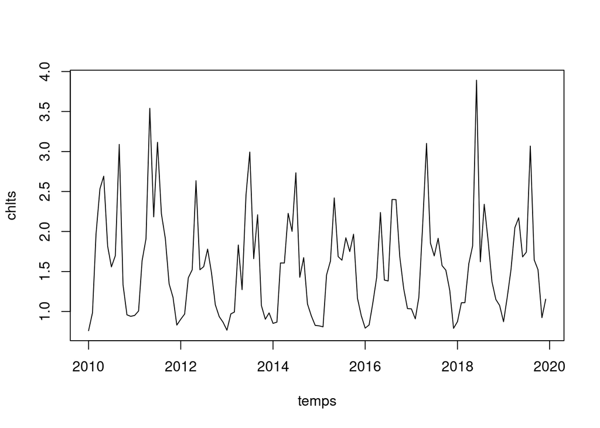

```r
chl<-chlpetit

#serie temporelle
chlts<-cellStats(chl,stat="mean",na.rm=T)
#vecteur temporel
temps<-strptime(gsub("X","",names(chlts)),"%Y.%m.%d")
plot(temps,chlts,type="l")
```

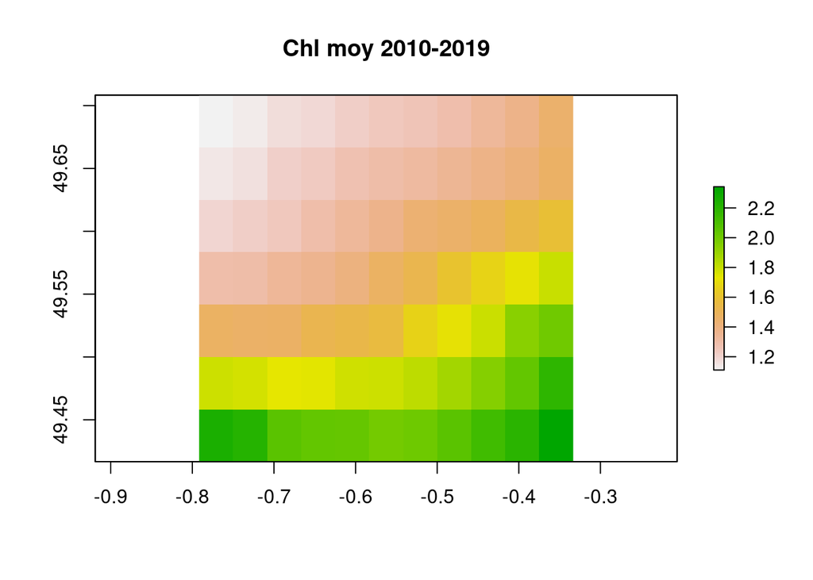

```r
#calcul de la moyenne et affichage
meanchl<-mean(chl,na.rm=TRUE)
plot(meanchl)
title("Chl moy 2010-2019")
#pour ajouter le trait de côte
map("worldHires",xlim=c(-1.5,0.8),ylim=c(49.2,49.7),col="light grey",fill=T,add=T)
```

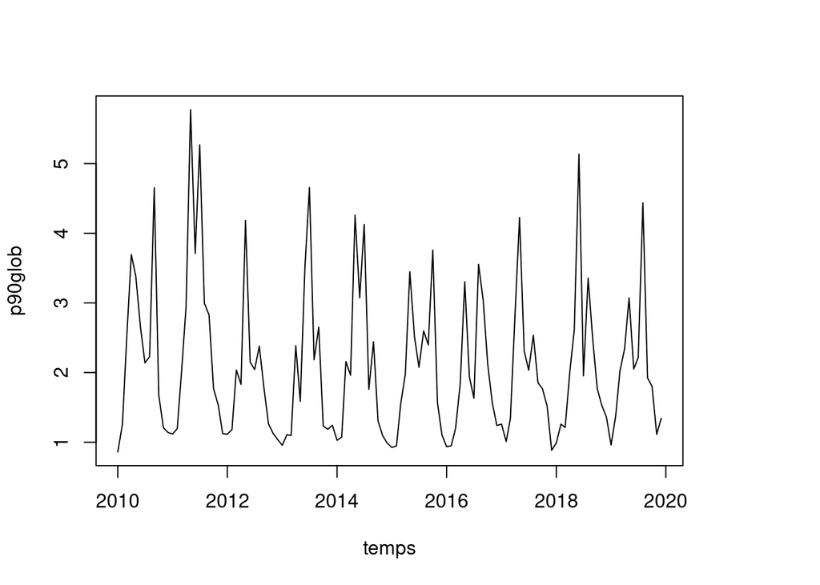

```r
#le quantile à 90% des cartes
p90glob<-quantile(chl,0.9)
temps<-strptime(gsub("X","",rownames(p90glob)),"%Y.%m.%d")
plot(temps,p90glob,type="l")
```

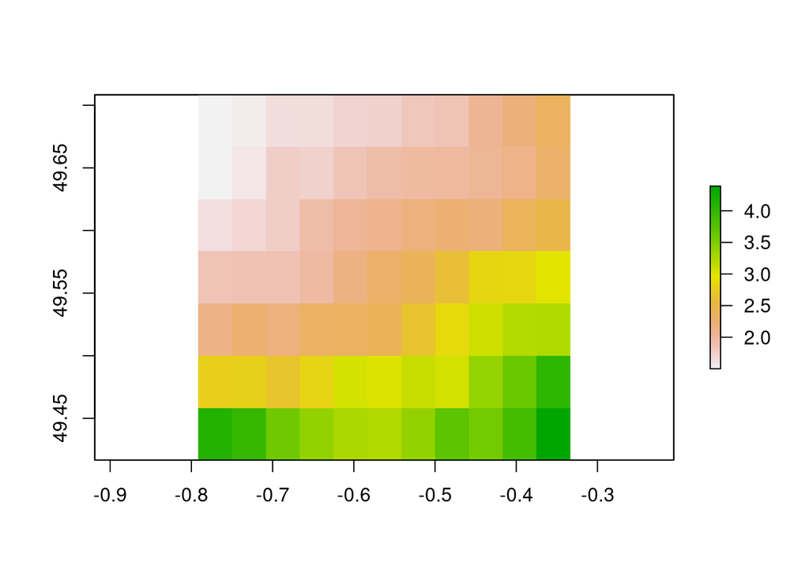

```r
#un fonction pour calculer le p90 sur une serie
p90<-function(a,na.rm=T){
  p90tmp<-quantile(a,probs=.9,na.rm=T)
  return(p90tmp)
}

#calcul du P90 par pixel
chlp90<-stackApply(chl,rep(1,nlayers(chl)),p90)

plot(chlp90)
```